# Targeting poverty in Costa Rica: predicting which households are poor

Hermann and Zoltan

14 November 2026

# 1. Application context

Governments want to direct social transfers to the poorest households. In Latin America many workers are informal, so income is hard to verify. Countries therefore use *proxy means tests*: they predict poverty from observable household characteristics (dwelling, assets, household composition, education) instead of income (Caruso, Galiani and Weinschelbaum, 2019).

**Data.** Household survey from Costa Rica (Inter-American Development Bank, released on Kaggle: “Costa Rican Household Poverty Level Prediction”). The original data has one row per person (9,557 persons in 2,988 households). Because the poverty label belongs to the household, we keep **one row per household (the household head)**. Otherwise members of the same household could end up in both the training and the test data. After cleaning we have **2,970 households and 43 predictors**.

**Task.** Classification: is a household *poor* (extreme or moderate poverty) or *not poor* (vulnerable or non-vulnerable)? This mirrors the decision of a targeting programme: is the household eligible or not? The label `poor` is known for every household in the survey. We use it to train the models and to check them on households that the models have not seen.

**Why the type of error matters.** Classifying a poor household as not poor excludes it from support. Classifying a non-poor household as poor wastes resources. Which error is worse is a policy choice, so besides the error rate we use sensitivity, specificity and the AUC.

**Related work.** Kim (2021) fits a random forest and gradient boosted trees to the original four-class problem on the same data and also finds education to be the most important predictor. Our set-up differs (binary target, one row per household).

# 2. The data: variables and meaning

`head_` refers to the household head, `n_` means “number of”. In the exploratory analysis categorical variables are factors (one variable instead of many 0/1 columns).

| Group | Variables | Meaning | Why we expect it to matter |
| --- | --- | --- | --- |
| Household head | `head_age`, `head_male`, `head_marital_status`, `head_education_level`, `head_years_schooling`, `head_disabled` | Characteristics of the head | Education is the classic driver of earnings; female-headed households are often poorer |
| Composition | `household_size`, `persons_living_in_dwelling`, `n_children_0_19`, `n_seniors_65plus`, `n_males_under12`, `n_males_12plus`, `n_females_under12`, `n_females_12plus`, `dependency_rate`, `mean_years_scho… | Size and age structure; dependency rate = (members under 19 or over 64) / members aged 19-64; average schooling of adults | Many dependants per earner and low adult education mean low income per person |
| Dwelling | `n_rooms`, `n_bedrooms`, `persons_per_bedroom`, `overcrowded_bedrooms`, `overcrowded_rooms`, `housing_tenure`, `monthly_rent`, `wall_material`, `wall_quality`, `roof_material`, `roof_quality`, `has_ce… | Size, crowding, tenure and building quality | Dwelling quality is the core of a proxy means test |
| Services | `water_supply`, `electricity_source`, `toilet_type`, `has_toilet`, `cooking_energy`, `rubbish_disposal` | Access to water, electricity, sanitation, cooking fuel, waste collection | Lack of basic services signals deprivation |
| Assets | `has_refrigerator`, `has_computer`, `has_television`, `n_tablets`, `n_mobile_phones` | Durable goods | Assets are a direct proxy of wealth |
| Location | `region`, `urban` | Planning region; urban (1) or rural (0) | Regional and rural-urban gaps in development |
| **Target** | `poor` | `poor` = original groups 1-2, `not_poor` = groups 3-4 |  |

```r
predictors <- setdiff(names(costa_rica), "poor")
X <- costa_rica[predictors]

# type of each predictor: categorical (factor), binary (0/1) or numeric
var_type <- sapply(X, function(x) {
  if (is.factor(x)) "categorical"
  else if (all(x %in% c(0, 1))) "binary 0/1"
  else "numeric"
})
table(var_type)
```

```
## var_type
##  binary 0/1 categorical     numeric
##          10          15          18
```

```r
# helper: to which original variable does a column of the model data belong?
# (e.g. "wall_material_wood" -> "wall_material"; numeric columns keep their name)
col_to_var <- function(cols) {
  sapply(cols, function(cn) {
    hits <- predictors[startsWith(cn, predictors)]
    hits[which.max(nchar(hits))]
  }, USE.NAMES = FALSE)
}

dim(costa_rica)          # readable version: households x (predictors + poor)
```

```
## [1] 2970   44
```

```r
dim(costa_rica_model)    # model version:    households x (columns + poor)
```

```
## [1] 2970   86
```

```r
sum(is.na(costa_rica)) + sum(is.na(costa_rica_model))   # missing values left
```

```
## [1] 0
```

In the model version every category is its own 0/1 column named `<variable>_<category>`, for example `wall_material_wood` = 1 if the walls are made of wood, 0 otherwise.

## Data cleaning (script `01_clean_data.R`)

| Step | Decision | Reason |
| --- | --- | --- |
| Unit of observation | Kept only the household head (9,557 persons -> 2,973 households) | The poverty label is a household outcome. Several rows per household would put the same household in training and test data (leakage). |
| Households without a head | 15 of 2,988 households dropped (0.5%) | They have no head row to keep. |
| Target | Built `poor` from the head’s 4-class group and removed the 4-class variable | A binary target is simpler and mirrors the eligibility decision. Keeping the 4-class variable would predict `poor` perfectly (leakage). In 85 households the members disagree on the group, so we use th… |
| Text values | “yes”/“no” in `dependency_rate` set to 1/0 | Checked against the squared columns of the original data. |
| Structural missing values | `monthly_rent` and `n_tablets` set to 0 when missing | They are missing exactly when the household pays no rent / owns no tablet, so 0 is the true value. |
| Other missing values | 3 households without adult schooling dropped; `rez_esc` (missing for all but one head) removed | Dropping 3 of 2,973 rows is negligible. `rez_esc` is only defined for school-age persons. |
| Redundant columns | Removed squared copies, exact sums of other columns, duplicates and constant columns | They add no information and only create collinearity. |
| Categories | Merged the 0/1 columns of one characteristic into one factor (for example `wall_material`) with readable labels; households in none of the listed categories get the label `not_recorded` | Easier to read. These are hidden missing values (for example `roof_material` 19 households). |
| Dummy variables | Model data: one 0/1 column for every category, no reference category | Every category gets its own coefficient, which is easy to interpret and compare. |
| Rare columns | 0/1 columns in which one value occurs in fewer than 30 households are removed | The effect of such a column cannot be estimated reliably (with 22% poor, 30 households contain only about 7 poor ones). No household is removed and the target is not used. |

**Result:** 2970 households, 43 predictors in the readable data (15 categorical, 10 binary, 18 numeric) and 85 0/1 or numeric columns in the model data. No missing values, one row per household.

**What we can rely on:** each household appears once, the target is consistent with the variables, the only recodings of values (“yes”/“no”, structural zeros) were checked against other columns, and no predictor contains information on the target (no leakage). Nothing was removed because of its relation to poverty; variable selection is left to the models, inside cross-validation.

**Limitations (kept on purpose):**

- The data describe the household head and the dwelling, not every member.
- The classes are imbalanced (22% poor).
- Some columns are strongly correlated (see section 6.2).
- Rent is skewed and the dependency rate is capped.

# 3. The target

```r
table(costa_rica$poor)
```

```
##
## not_poor     poor
##     2306      664
```

```r
round(100 * prop.table(table(costa_rica$poor)), 1)
```

```
##
## not_poor     poor
##     77.6     22.4
```

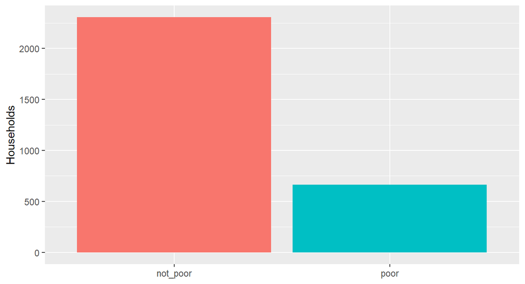

```r
ggplot(costa_rica, aes(poor, fill = poor)) + geom_bar() +
  labs(x = NULL, y = "Households") + theme(legend.position = "none")
```

22% of the households are poor (664 of 2970). The rule “nobody is poor” is already right for 78% of the households, so **accuracy alone is misleading**. We evaluate with sensitivity, specificity and AUC.

# 4. Who is poor? Descriptive analysis

```r
overall <- 100 * mean(costa_rica$poor == "poor")

# bar chart of the poverty rate for each group, with the number of households (n)
plot_rate <- function(group, title) {
  d <- data.frame(group = group, poor = costa_rica$poor == "poor")
  d <- d[!is.na(d$group), ]
  r <- aggregate(poor ~ group, d, function(x) c(rate = 100 * mean(x), n = length(x)))
  r <- data.frame(group = r$group, rate = r$poor[, "rate"], n = r$poor[, "n"])
  ggplot(r, aes(reorder(group, rate), rate)) + geom_col() +
    geom_text(aes(label = paste0("n=", n)), hjust = -0.1, size = 3) +
    geom_hline(yintercept = overall, linetype = "dashed") +
    coord_flip() + scale_y_continuous(limits = c(0, 100)) +
    labs(x = NULL, y = "Poverty rate (%)", title = title, subtitle = "dashed: overall rate")
}
```

**Education, region, area and sex of the head**

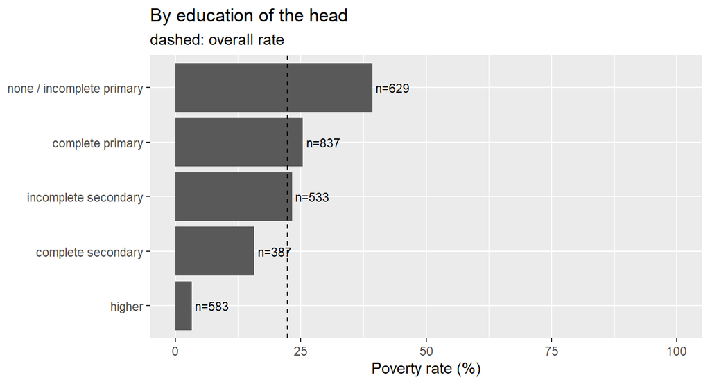

```r
# education of the head in 5 groups (the household with level "not_recorded" is left out)
edu_map <- c(none = "none / incomplete primary",
             incomplete_primary = "none / incomplete primary",
             complete_primary = "complete primary",
             incomplete_secondary = "incomplete secondary",
             incomplete_technical_secondary = "incomplete secondary",
             complete_secondary = "complete secondary",
             complete_technical_secondary = "complete secondary",
             undergraduate_or_higher = "higher",
             postgraduate = "higher")
edu_group <- unname(edu_map[as.character(costa_rica$head_education_level)])

plot_rate(edu_group, "By education of the head")
```

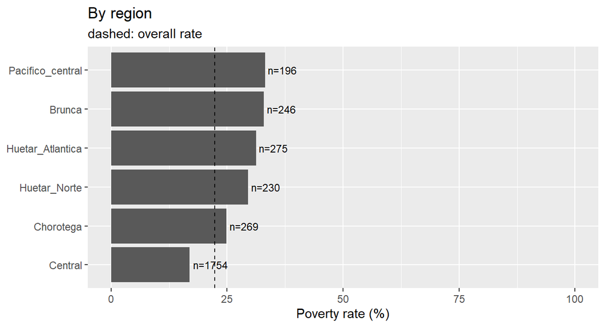

```r
plot_rate(costa_rica$region, "By region")
```

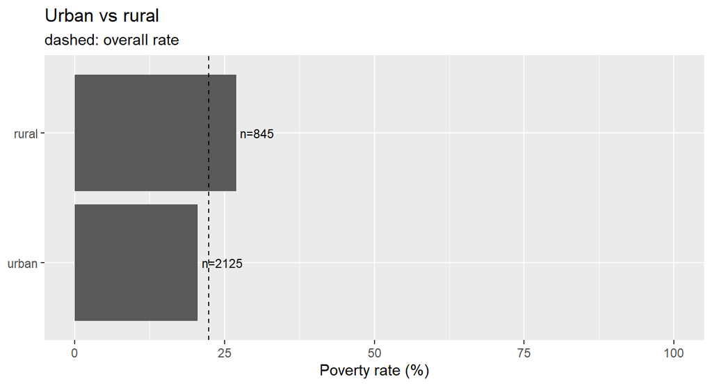

```r
plot_rate(ifelse(costa_rica$urban == 1, "urban", "rural"), "Urban vs rural")
```

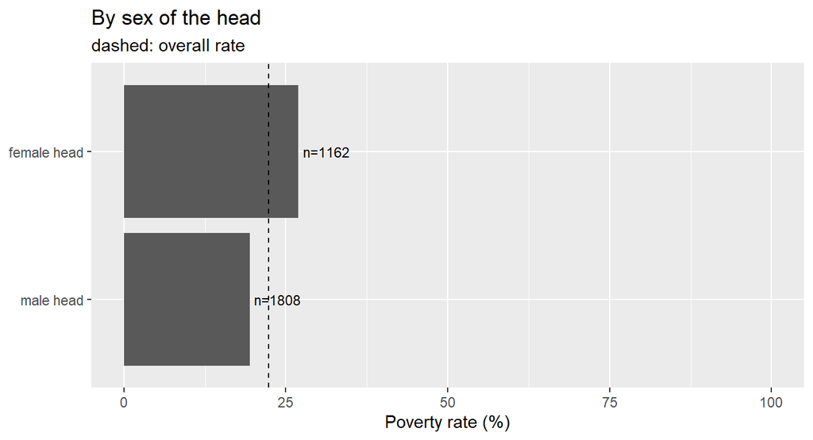

```r
plot_rate(ifelse(costa_rica$head_male == 1, "male head", "female head"), "By sex of the head")
```

**Assets and dwelling**

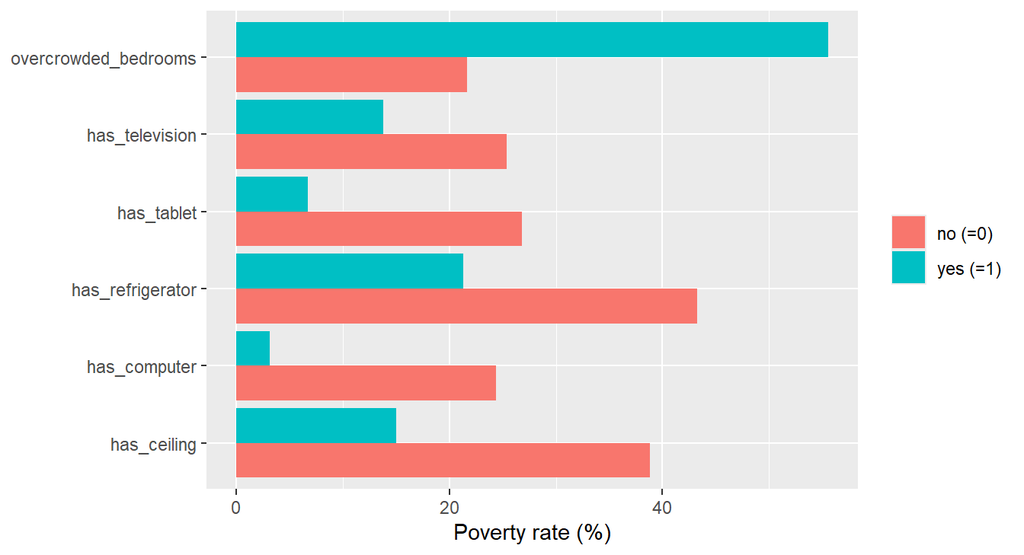

```r
# for each 0/1 indicator: poverty rate of households with (=1) and without (=0)
assets <- data.frame(
  has_computer         = costa_rica$has_computer,
  has_tablet           = as.numeric(costa_rica$n_tablets > 0),
  has_refrigerator     = costa_rica$has_refrigerator,
  has_television       = costa_rica$has_television,
  has_ceiling          = costa_rica$has_ceiling,
  overcrowded_bedrooms = costa_rica$overcrowded_bedrooms)
long <- do.call(rbind, lapply(names(assets), function(v)
  data.frame(var = v, has = ifelse(assets[[v]] == 1, "yes (=1)", "no (=0)"),
             poor = costa_rica$poor == "poor")))
res_assets <- aggregate(poor ~ var + has, long, function(x) 100 * mean(x))
ggplot(res_assets, aes(var, poor, fill = has)) + geom_col(position = "dodge") +
  coord_flip() + labs(x = NULL, y = "Poverty rate (%)", fill = NULL)
```

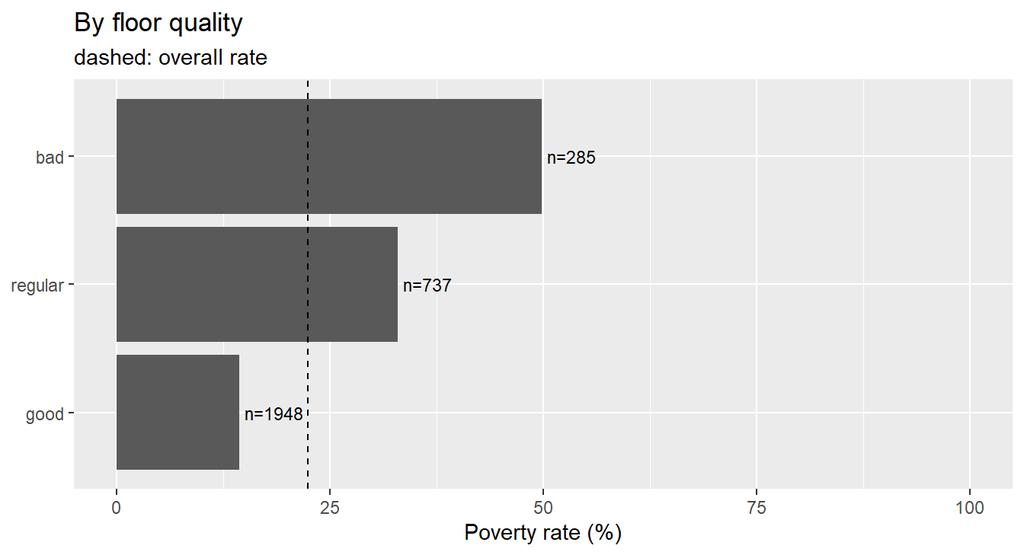

```r
plot_rate(costa_rica$floor_quality, "By floor quality")
```

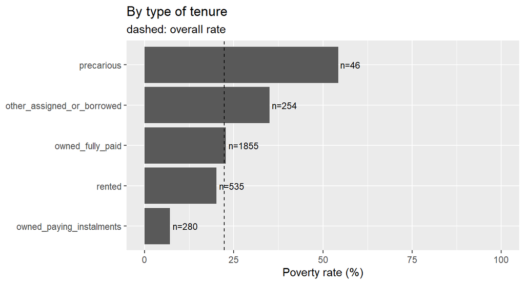

```r
plot_rate(costa_rica$housing_tenure, "By type of tenure")
```

**Numeric variables**

```r
num_vars <- c("head_years_schooling", "mean_years_schooling_adults",
              "persons_per_bedroom", "n_children_0_19",
              "household_size", "dependency_rate")
summary(costa_rica[num_vars])
```

```
##  head_years_schooling mean_years_schooling_adults persons_per_bedroom
##  Min.   : 0.000       Min.   : 0.000              Min.   :0.250
##  1st Qu.: 6.000       1st Qu.: 6.000              1st Qu.:1.000
##  Median : 7.000       Median : 8.667              Median :1.333
##  Mean   : 8.149       Mean   : 9.150              Mean   :1.376
##  3rd Qu.:11.000       3rd Qu.:12.000              3rd Qu.:1.667
##  Max.   :21.000       Max.   :37.000              Max.   :6.000
##  n_children_0_19  household_size   dependency_rate
##  Min.   :0.0000   Min.   : 1.000   Min.   :0.000
##  1st Qu.:0.0000   1st Qu.: 2.000   1st Qu.:0.000
##  Median :1.0000   Median : 3.000   Median :0.500
##  Mean   :0.9663   Mean   : 3.213   Mean   :1.327
##  3rd Qu.:2.0000   3rd Qu.: 4.000   3rd Qu.:1.000
##  Max.   :9.0000   Max.   :13.000   Max.   :8.000
```

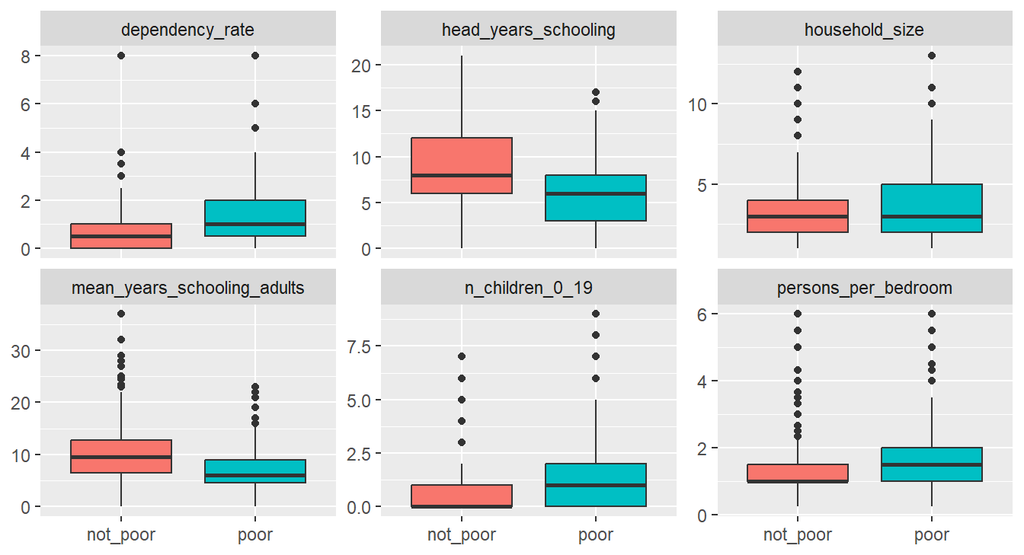

```r
long <- data.frame(poor  = rep(costa_rica$poor, length(num_vars)),
                   var   = rep(num_vars, each = nrow(costa_rica)),
                   value = unlist(costa_rica[num_vars], use.names = FALSE))
ggplot(long, aes(poor, value, fill = poor)) + geom_boxplot() +
  facet_wrap(~ var, scales = "free_y") + labs(x = NULL, y = NULL) +
  theme(legend.position = "none")
```

# 5. Which variables are most related to poverty?

We use the model data, in which every category is its own 0/1 column. Each category then gets its own correlation with `poor` (1 = poor). A correlation has no units, so numeric variables and categories can be compared directly. Positive = more often poor.

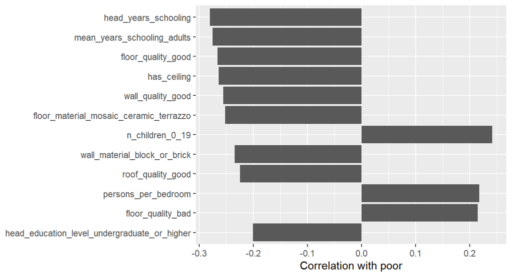

```r
Xd <- as.matrix(costa_rica_model[, setdiff(names(costa_rica_model), "poor")])
Xd <- Xd[, apply(Xd, 2, sd) > 0]                      # drop constant columns
y  <- as.numeric(costa_rica_model$poor == "poor")
cors <- apply(Xd, 2, function(x) cor(x, y))

top <- head(cors[order(-abs(cors))], 12)
ggplot(data.frame(var = names(top), r = top), aes(reorder(var, abs(r)), r)) +
  geom_col() + coord_flip() + labs(x = NULL, y = "Correlation with poor")
```

The same information with one line per original variable (its strongest column):

```r
by_var <- split(cors, col_to_var(names(cors)))        # correlations grouped by variable
cor_tab <- data.frame(
  variable         = names(by_var),
  strongest_column = sapply(by_var, function(r) names(r)[which.max(abs(r))]),
  correlation      = sapply(by_var, function(r) r[which.max(abs(r))]),
  row.names = NULL)
cor_tab$type <- unname(var_type[cor_tab$variable])
cor_tab$correlation <- round(cor_tab$correlation, 3)
cor_tab <- cor_tab[order(-abs(cor_tab$correlation)),
                   c("variable", "type", "strongest_column", "correlation")]
knitr::kable(head(cor_tab, 15), row.names = FALSE,
             caption = "Strongest correlation with poverty for each variable")
```

Strongest correlation with poverty for each variable

| variable | type | strongest_column | correlation |
| --- | --- | --- | --- |
| head_years_schooling | numeric | head_years_schooling | -0.280 |
| mean_years_schooling_adults | numeric | mean_years_schooling_adults | -0.276 |
| floor_quality | categorical | floor_quality_good | -0.266 |
| has_ceiling | binary 0/1 | has_ceiling | -0.264 |
| wall_quality | categorical | wall_quality_good | -0.256 |
| floor_material | categorical | floor_material_mosaic_ceramic_terrazzo | -0.252 |
| n_children_0_19 | numeric | n_children_0_19 | 0.242 |
| wall_material | categorical | wall_material_block_or_brick | -0.234 |
| roof_quality | categorical | roof_quality_good | -0.225 |
| persons_per_bedroom | numeric | persons_per_bedroom | 0.217 |
| head_education_level | categorical | head_education_level_undergraduate_or_higher | -0.201 |
| n_females_under12 | numeric | n_females_under12 | 0.188 |
| n_rooms | numeric | n_rooms | -0.181 |
| n_males_under12 | numeric | n_males_under12 | 0.170 |
| n_tablets | numeric | n_tablets | -0.170 |

These are simple associations that ignore all other variables.

# 6. Issues for the modelling stage

## 6.1 Rare categories (already handled in the cleaning step)

Some categories contain very few households. The effect of such a category cannot be estimated reliably: with 22% poor households, a category of 30 households contains only about 7 poor ones. In the cleaning script we therefore removed every 0/1 column in which one of the two values occurs in fewer than 30 households.

**No household was removed.** The households of a removed category stay in the data with 0 in all remaining columns of that variable. Removing the households themselves would drop some of the most deprived ones (for example no floor or no electricity), exactly the cases a targeting programme most needs to find.

```r
cat_vars <- predictors[sapply(costa_rica[predictors], is.factor)]
counts <- do.call(rbind, lapply(cat_vars, function(v) {
  t <- table(costa_rica[[v]])
  data.frame(variable = v, category = names(t), n = as.integer(t),
             share_pct = round(100 * as.numeric(t) / nrow(costa_rica), 1))
}))
counts <- counts[order(counts$n), ]
rownames(counts) <- NULL
knitr::kable(head(counts, 15), caption = "The 15 rarest categories (readable data, before removal)")
```

The 15 rarest categories (readable data, before removal)

| variable | category | n | share_pct |
| --- | --- | --- | --- |
| head_education_level | not_recorded | 1 | 0.0 |
| floor_material | other | 2 | 0.1 |
| electricity_source | private_plant | 2 | 0.1 |
| floor_material | natural_material | 3 | 0.1 |
| wall_material | other | 4 | 0.1 |
| electricity_source | not_recorded | 4 | 0.1 |
| rubbish_disposal | thrown_in_unoccupied_space | 4 | 0.1 |
| rubbish_disposal | other | 4 | 0.1 |
| wall_material | natural_fibers | 5 | 0.2 |
| roof_material | other | 7 | 0.2 |
| toilet_type | other | 7 | 0.2 |
| roof_material | natural_fibers | 9 | 0.3 |
| electricity_source | none | 9 | 0.3 |
| water_supply | none | 11 | 0.4 |
| toilet_type | none | 15 | 0.5 |

```r
knitr::kable(removed_cols, caption = "0/1 columns removed (fewer than 30 households)")
```

0/1 columns removed (fewer than 30 households)

| column | households_in_rarer_value |
| --- | --- |
| head_education_level_not_recorded | 1 |
| floor_material_other | 2 |
| electricity_source_private_plant | 2 |
| floor_material_natural_material | 3 |
| wall_material_other | 4 |
| electricity_source_not_recorded | 4 |
| rubbish_disposal_thrown_in_unoccupied_space | 4 |
| rubbish_disposal_other | 4 |
| wall_material_natural_fibers | 5 |
| roof_material_other | 7 |
| toilet_type_other | 7 |
| roof_material_natural_fibers | 9 |
| electricity_source_none | 9 |
| water_supply_none | 11 |
| toilet_type_none | 15 |
| cooking_energy_none_no_kitchen | 15 |
| has_toilet | 17 |
| roof_material_not_recorded | 19 |
| head_education_level_incomplete_technical_secondary | 20 |
| wall_material_waste_material | 25 |

20 columns were removed. The model data have 85 columns (predictors), all with at least 30 households in each of their two values.

## 6.2 Strongly correlated columns

```r
cm <- cor(Xd)
h <- which(abs(cm) >= 0.9 & upper.tri(cm), arr.ind = TRUE)
high_pairs <- data.frame(var1 = rownames(cm)[h[, 1]], var2 = colnames(cm)[h[, 2]],
                         r = round(cm[h], 3))
high_pairs                                     # pairs with |correlation| >= 0.9
```

| var1 | var2 | r |
| --- | --- | --- |
| household_size | persons_living_in_dwelling | 0.927 |
| water_supply_inside_dwelling | water_supply_outside_dwelling | -0.940 |
| electricity_source_public_grid | electricity_source_cooperative | -0.975 |
| toilet_type_sewer_or_cesspool | toilet_type_septic_tank | -0.944 |
| cooking_energy_electricity | cooking_energy_gas | -0.902 |

```r
mean(costa_rica$monthly_rent > 0)              # share of households paying rent
```

```
## [1] 0.2723906
```

5 pairs of columns have an absolute correlation of at least 0.9 (mostly categories of the same variable, and household size with persons living in the dwelling). Regularization (lasso, ridge) handles this, and trees are not affected. Only 27.2% of the households pay rent (for the others the value is 0).

# 7. Main findings of the exploratory analysis

- **22% of households are poor**: the classes are imbalanced, so accuracy alone is not informative.
- **Education is the strongest signal.** The poverty rate falls from 39% (head with no or incomplete primary education) to 3% (higher education). The variable with the strongest correlation to `poor` is head_years_schooling (-0.28).
- **Dwelling quality and assets matter.** Poverty is 3% in households with a computer against 24% without. Households with bad floors or walls or no ceiling are also poorer (see the plots above).
- **Geography and sex of the head.** 17% poor in the Central region against 25-33% in the other regions; rural 27% against urban 21%; female-headed 27% against male-headed 19%.
- **No single variable is a strong predictor**: the largest absolute correlation is 0.28. We need models that combine many variables.
- **Modelling implications.** The 43 predictors become 85 model columns when every category gets its own 0/1 column; 5 pairs of columns are strongly correlated. This motivates regularization (lasso) and variable selection inside cross-validation. Trees and boosting handle the skewed rent and the capped dependency rate without transformation.

**Sources.** Caruso, M., Galiani, S., Weinschelbaum, F. (2019). *Poverty Alleviation Strategies Under Informality: Evidence for Latin America.* NBER Working Paper 26339. Kim, J. Y. (2021). *Using Machine Learning to Predict Poverty Status in Costa Rican Households.* arXiv:2111.13319. Data: Inter-American Development Bank via Kaggle.

# 8. Pre-processing and variable selection prior to the analysis

**Already done in the cleaning step** (it does not use the outcome, so there is no leakage): one row per household; “yes”/“no” recoded; structural missing values set to 0; squared copies, exact sums, duplicates and constant columns removed; one 0/1 column for every category; 0/1 columns with fewer than 30 households removed.

**Steps before the models**

1. **Train/test split (70/30, stratified).** Following unit 4, we hold out a test set for the final assessment of the chosen model. The data set is not large, so tuning and model selection use 10-fold cross-validation on the training set instead of a separate validation set. The split is done first, with a fixed seed, and keeps the share of poor households in both parts. The test set is used only once, at the end.
2. **Encoding.** The model data already contain one 0/1 column per category, so all methods see exactly the same numeric matrix. Columns that are constant in the training set are removed.
3. **Scaling.** The penalty of the lasso depends on the scale of the variables, so they are standardized (`glmnet` does this internally and reports coefficients on the original scale). Trees and boosting are not affected by scale.
4. **Skewed variables (rent, dependency rate).** Left unchanged: tree-based methods are invariant to monotone transformations, and the penalty handles the rest.
5. **Class imbalance (22% poor).** We keep the natural class frequencies and evaluate with AUC, sensitivity and specificity instead of accuracy. The classification threshold can be adjusted afterwards (unit 4).
6. **Variable selection.** We do not drop variables by hand. Selecting variables by their relation to the outcome and then cross-validating would give an optimistic error (unit 4). Selection is part of the methods: the lasso sets coefficients exactly to zero, and for random forest and boosting we use variable importance. Everything is tuned by cross-validation on the training set only.

```r
set.seed(2026)

# 1. stratified 70/30 split (same share of poor households in both parts)
idx_poor <- which(costa_rica$poor == "poor")
idx_not  <- which(costa_rica$poor == "not_poor")
train_id <- c(sample(idx_poor, round(0.7 * length(idx_poor))),
              sample(idx_not,  round(0.7 * length(idx_not))))
train <- costa_rica[train_id, ]      # same households, same order as costa_rica_model
test  <- costa_rica[-train_id, ]
table(train$poor); table(test$poor)
```

```
##
## not_poor     poor
##     1614      465
```

```
##
## not_poor     poor
##      692      199
```

```r
round(100 * prop.table(table(train$poor)), 1)
```

```
##
## not_poor     poor
##     77.6     22.4
```

```r
round(100 * prop.table(table(test$poor)), 1)
```

```
##
## not_poor     poor
##     77.7     22.3
```

```r
# 2. input matrices from the model data (one 0/1 column per category)
x_all   <- as.matrix(costa_rica_model[, setdiff(names(costa_rica_model), "poor")])
x_train <- x_all[train_id, ]
x_test  <- x_all[-train_id, ]
y_train <- train$poor
y_test  <- test$poor

# columns that are constant in the training set carry no information
keep <- apply(x_train, 2, sd) > 0
x_train <- x_train[, keep]
x_test  <- x_test[, keep]
dim(x_train)                         # training households x columns
```

```
## [1] 2079   85
```

# 9. Predictive models: lasso, random forest and boosting

We fit three methods from class to predict `poor`. All three use the same inputs (`x_train`, `y_train`) and the same 10-fold cross-validation folds on the training set, so the comparison is fair. The test set is not touched here.

| Method | Unit | Hyperparameters tuned by 10-fold CV |
| --- | --- | --- |
| Logistic regression with lasso penalty (package glmnet) | 2-3 | penalty lambda |
| Random forest (package randomForest) | 6 | mtry (variables tried per split) |
| Boosting, gradient boosted trees (package gbm) | 7 | number of trees, tree depth, learning rate |

The tuning criterion is the AUC (area under the ROC curve), because the classes are imbalanced and accuracy would be misleading.

## Step 1: Common set-up

A **hyperparameter** is a setting that the method does not learn from the data, and we have to choose it. For each candidate value we fit on 9 folds, measure the AUC on the 10th fold, and average over the 10 rounds. The folds are fixed once, so all methods are compared on exactly the same folds. The folds run in parallel on several cores to save time.

The fitted models are saved in the folder `models`. If a saved model exists, it is loaded instead of being fitted again. (Delete the folder `models` to refit everything, for example after changing the data or the tuning grids.)

```r
set.seed(2026)
folds <- createFolds(y_train, k = 10, returnTrain = TRUE)   # stratified folds

ctrl <- trainControl(
  method = "cv", number = 10, index = folds,   # same 10 folds for every method
  classProbs = TRUE,                           # probabilities are needed for the AUC
  summaryFunction = twoClassSummary)           # reports AUC ("ROC"), Sens, Spec
```

```r
dir.create("models", showWarnings = FALSE)      # folder for the fitted models

# fits a model only if no saved file exists; otherwise loads the saved model
load_or_fit <- function(file, fit_expr) {
  path <- file.path("models", file)
  if (file.exists(path)) {
    message("Loading saved model: ", path)
    return(readRDS(path))
  }
  fit <- fit_expr                               # the model is fitted here, only when needed
  saveRDS(fit, path)
  fit
}
```

```r
cl <- makePSOCKcluster(max(1, parallel::detectCores() - 1))   # all cores but one
registerDoParallel(cl)
```

## Step 2: Model 1 - Logistic regression with lasso penalty

The lasso fits a logistic regression and adds a penalty on the sum of the absolute values of the coefficients. A larger lambda shrinks more, and weak variables get a coefficient of exactly zero. A small lambda means little penalty (risk of overfitting); a large lambda removes many variables (risk of underfitting). We try 30 values of lambda and keep the best one by cross-validated AUC. (`alpha = 1` means lasso; the variables are standardized internally.)

```r
set.seed(2026)
fit_lasso <- load_or_fit("fit_lasso.rds", train(
  x = x_train, y = y_train,
  method = "glmnet",
  metric = "ROC",                              # choose lambda by cross-validated AUC
  trControl = ctrl,
  tuneGrid = expand.grid(alpha = 1,            # alpha = 1: lasso
                         lambda = 10^seq(-4, -1, length.out = 30))))

fit_lasso$bestTune                             # chosen lambda
```

|  | alpha | lambda |
| --- | --- | --- |
| 12 | 1 | 0.001373824 |

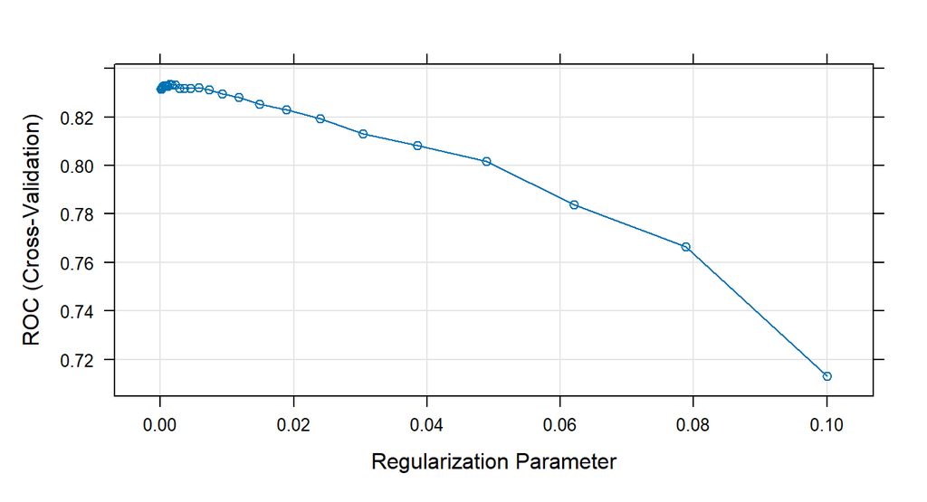

```r
plot(fit_lasso)                                # CV-AUC for each lambda
```

How many columns does the lasso keep (coefficient not exactly zero)?

```r
cf_all <- as.matrix(coef(fit_lasso$finalModel, s = fit_lasso$bestTune$lambda))[-1, 1]
c(columns_total = length(cf_all), columns_kept = sum(cf_all != 0))
```

```
## columns_total  columns_kept
##            85            70
```

A positive coefficient raises the probability of being poor, a negative one lowers it, holding the other variables fixed. The coefficients are discussed in section 12.

## Step 3: Model 2 - Random forest

A random forest grows many decision trees, each on a random bootstrap sample of the households. At each split a tree may only look at a random subset of `mtry` variables. The final prediction is the vote of all trees, which is much more stable than a single tree (averaging reduces variance). We use 300 trees and tune `mtry`: a small `mtry` makes the trees different from each other, a large `mtry` makes each tree stronger but more similar.

```r
set.seed(2026)
fit_rf <- load_or_fit("fit_rf.rds", train(
  x = x_train, y = y_train,
  method = "rf",
  metric = "ROC",
  trControl = ctrl,
  tuneGrid = data.frame(mtry = c(3, 6, 10, 15)),
  ntree = 300))

fit_rf$bestTune                                # chosen mtry
```

|  | mtry |
| --- | --- |
| 2 | 6 |

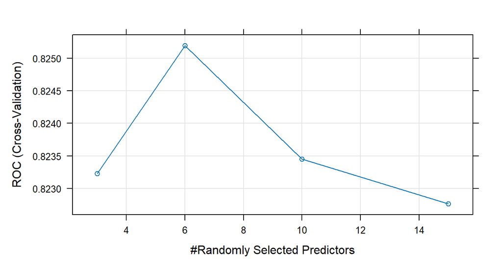

```r
plot(fit_rf)                                   # CV-AUC for each mtry
```

Which variables matter most for the forest?

```r
imp_rf <- varImp(fit_rf, scale = TRUE)$importance
imp_rf <- imp_rf[order(-imp_rf$Overall), , drop = FALSE]
knitr::kable(head(imp_rf, 15), digits = 1, caption = "Random forest: variable importance (100 = most important)")
```

Random forest: variable importance (100 = most important)

|  | Overall |
| --- | --- |
| mean_years_schooling_adults | 100.0 |
| head_age | 77.1 |
| dependency_rate | 77.0 |
| head_years_schooling | 67.1 |
| persons_per_bedroom | 63.7 |
| n_mobile_phones | 51.0 |
| n_children_0_19 | 48.4 |
| n_rooms | 43.7 |
| persons_living_in_dwelling | 36.8 |
| household_size | 35.6 |
| n_males_12plus | 32.9 |
| n_bedrooms | 30.4 |
| monthly_rent | 30.0 |
| n_females_under12 | 29.9 |
| floor_quality_good | 29.2 |

## Step 4: Model 3 - Boosting

Boosting also uses trees, but builds them one after another: each small tree is fit to the mistakes of the current model, and its contribution is added with a small weight (the learning rate). Each step improves the model a little (boosting reduces bias). We tune three hyperparameters:

- `n.trees`: number of trees (too many can overfit),
- `interaction.depth`: size of each tree (1 = single splits only, 3 = up to three variables interact),
- `shrinkage`: learning rate (small = slow, careful learning, needs more trees).

```r
set.seed(2026)
fit_gbm <- load_or_fit("fit_gbm.rds", train(
  x = x_train, y = y_train,
  method = "gbm",
  metric = "ROC",
  trControl = ctrl,
  tuneGrid = expand.grid(n.trees = c(100, 300, 500),
                         interaction.depth = c(1, 2, 3),
                         shrinkage = c(0.01, 0.05),
                         n.minobsinnode = 10),   # minimum households per leaf (fixed)
  verbose = FALSE))

fit_gbm$bestTune                               # chosen combination
```

|  | n.trees | interaction.depth | shrinkage | n.minobsinnode |
| --- | --- | --- | --- | --- |
| 14 | 300 | 2 | 0.05 | 10 |

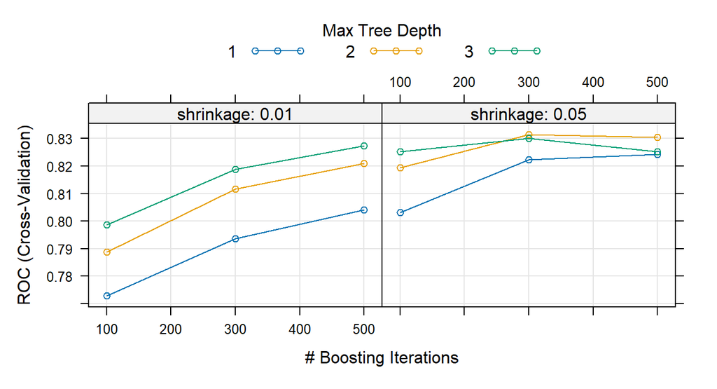

```r
plot(fit_gbm)                                  # CV-AUC for each combination
```

```r
imp_gbm <- varImp(fit_gbm, scale = TRUE)$importance
imp_gbm <- imp_gbm[order(-imp_gbm$Overall), , drop = FALSE]
knitr::kable(head(imp_gbm, 15), digits = 1, caption = "Boosting: variable importance (100 = most important)")
```

Boosting: variable importance (100 = most important)

|  | Overall |
| --- | --- |
| mean_years_schooling_adults | 100.0 |
| dependency_rate | 77.5 |
| persons_per_bedroom | 45.0 |
| n_children_0_19 | 37.8 |
| head_age | 32.1 |
| n_mobile_phones | 27.5 |
| has_ceiling | 25.4 |
| floor_quality_good | 25.1 |
| head_years_schooling | 24.6 |
| wall_material_block_or_brick | 17.9 |
| roof_quality_bad | 16.2 |
| monthly_rent | 15.2 |
| n_females_under12 | 15.0 |
| n_tablets | 13.5 |
| n_males_12plus | 11.6 |

```r
stopCluster(cl)                                # release the cores
registerDoSEQ()
```

## Step 5: Comparison of the three methods (cross-validation, training set)

Every method is shown with its best hyperparameters. The numbers are 10-fold CV estimates computed on the same folds. The AUC (“ROC”) is the main criterion. In this output “Sens” is the share of not-poor households correctly found and “Spec” the share of poor households correctly found, because caret treats the first factor level (not_poor) as the event. We therefore only use the AUC here, and compute sensitivity and specificity of the poor class on the test set.

```r
res <- resamples(list(Lasso = fit_lasso, RandomForest = fit_rf, Boosting = fit_gbm))
summary(res)
```

```
##
## Call:
## summary.resamples(object = res)
##
## Models: Lasso, RandomForest, Boosting
## Number of resamples: 10
##
## ROC
##                   Min.   1st Qu.    Median      Mean   3rd Qu.      Max. NA's
## Lasso        0.8100965 0.8191951 0.8280046 0.8333528 0.8390415 0.8725358    0
## RandomForest 0.7699632 0.8098813 0.8308565 0.8251914 0.8410019 0.8582231    0
## Boosting     0.8033567 0.8175401 0.8293563 0.8313983 0.8391894 0.8618688    0
##
## Sens
##                   Min.   1st Qu.    Median      Mean   3rd Qu.      Max. NA's
## Lasso        0.8757764 0.9316770 0.9347826 0.9336746 0.9426424 0.9691358    0
## RandomForest 0.9440994 0.9490166 0.9627329 0.9628096 0.9752703 0.9814815    0
## Boosting     0.9006211 0.9335461 0.9411855 0.9435894 0.9549689 0.9938272    0
##
## Spec
##                   Min.   1st Qu.    Median      Mean   3rd Qu.      Max. NA's
## Lasso        0.3617021 0.3729186 0.3871415 0.4283996 0.4867021 0.5434783    0
## RandomForest 0.1489362 0.2302266 0.3011101 0.2822849 0.3243525 0.3913043    0
## Boosting     0.3191489 0.3636679 0.3871415 0.4003238 0.4169750 0.5000000    0
```

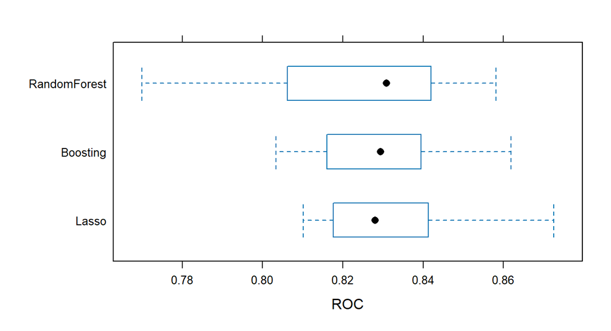

```r
bwplot(res, metric = "ROC")                    # the 10 AUC values of each method
```

# 10. Model selection

We compare the three methods with the cross-validated AUC on the training set. All three were evaluated on exactly the same 10 folds, so the comparison is fair and the test set plays no role in the choice.

```r
cv_table <- data.frame(
  Method = c("Lasso", "Random forest", "Boosting"),
  Best_hyperparameters = c(
    paste0("lambda = ", signif(fit_lasso$bestTune$lambda, 3)),
    paste0("mtry = ", fit_rf$bestTune$mtry),
    paste0(fit_gbm$bestTune$n.trees, " trees, depth ",
           fit_gbm$bestTune$interaction.depth, ", learning rate ",
           fit_gbm$bestTune$shrinkage)),
  CV_AUC_mean = c(mean(res$values[["Lasso~ROC"]]),
                  mean(res$values[["RandomForest~ROC"]]),
                  mean(res$values[["Boosting~ROC"]])),
  CV_AUC_sd = c(sd(res$values[["Lasso~ROC"]]),
                sd(res$values[["RandomForest~ROC"]]),
                sd(res$values[["Boosting~ROC"]])))
cv_table[3:4] <- round(cv_table[3:4], 3)
knitr::kable(cv_table, row.names = FALSE, caption = "Cross-validated AUC on the training set")
```

Cross-validated AUC on the training set

| Method | Best_hyperparameters | CV_AUC_mean | CV_AUC_sd |
| --- | --- | --- | --- |
| Lasso | lambda = 0.00137 | 0.833 | 0.020 |
| Random forest | mtry = 6 | 0.825 | 0.027 |
| Boosting | 300 trees, depth 2, learning rate 0.05 | 0.831 | 0.019 |

```r
# paired differences between methods over the 10 folds (t-tests, Bonferroni adjusted)
summary(diff(res, metric = "ROC"))
```

```
##
## Call:
## summary.diff.resamples(object = diff(res, metric = "ROC"))
##
## p-value adjustment: bonferroni
## Upper diagonal: estimates of the difference
## Lower diagonal: p-value for H0: difference = 0
##
## ROC
##              Lasso  RandomForest Boosting
## Lasso                0.008161     0.001955
## RandomForest 0.5082              -0.006207
## Boosting     1.0000 0.8152
```

The cross-validated AUC is 0.825 to 0.833 for the three methods, and the standard deviation across folds is about 0.022. The differences between the methods are small compared with this variation (see the paired tests), so we cannot say that one method predicts better than the others. We therefore choose by **parsimony**: the **lasso** is the simplest model, it is a linear model with coefficients that can be interpreted, and it predicts about as well as the flexible tree ensembles. This also suggests that non-linear effects and interactions, which the forest and boosting can capture, add little predictive power here.

**Check: ridge instead of lasso.** Ridge uses the same logistic regression with a penalty on the sum of squared coefficients: it keeps all variables and shrinks correlated columns together (unit 2). We tune it on the same folds to see whether it would be a better linear model.

```r
set.seed(2026)
fit_ridge <- load_or_fit("fit_ridge.rds", train(
  x = x_train, y = y_train,
  method = "glmnet", metric = "ROC", trControl = ctrl,
  tuneGrid = expand.grid(alpha = 0,                          # alpha = 0: ridge
                         lambda = 10^seq(-3, 1, length.out = 40))))

fit_ridge$bestTune                                           # should not be at the edge of the grid
```

|  | alpha | lambda |
| --- | --- | --- |
| 11 | 0 | 0.01060818 |

```r
res_lin <- resamples(list(Lasso = fit_lasso, Ridge = fit_ridge))
ridge_cmp <- data.frame(Method = c("Lasso", "Ridge"),
                        CV_AUC_mean = round(c(mean(res_lin$values[["Lasso~ROC"]]),
                                              mean(res_lin$values[["Ridge~ROC"]])), 3))
ridge_cmp
```

| Method | CV_AUC_mean |
| --- | --- |
| Lasso | 0.833 |
| Ridge | 0.832 |

Ridge reaches a cross-validated AUC of 0.832, against 0.833 for the lasso. If the two are close, we keep the lasso, which also selects variables.

# 11. Model assessment

The chosen model (lasso) is now assessed **once** on the test set, which was not used for fitting or tuning. We report the AUC with the ROC curve, and the confusion matrix with sensitivity and specificity of the poor class.

**Choice of the classification threshold.** The lasso outputs a probability of being poor. The default rule “poor if probability >= 0.5” is a poor fit for imbalanced data: with only 22% poor households the model tends to say “not poor”. We therefore also use a second threshold that maximizes sensitivity + specificity (Youden index). To avoid using the test set for this choice, it is computed on out-of-fold predictions of the training set: each training household is predicted by a lasso (with the chosen lambda) that was fit on the other folds.

```r
best_lambda <- fit_lasso$bestTune$lambda
oof <- rep(NA_real_, nrow(x_train))
for (f in folds) {                                  # f = rows used for fitting in this fold
  hold  <- setdiff(seq_len(nrow(x_train)), f)       # rows held out in this fold
  fit_f <- glmnet(x_train[f, ], y_train[f], family = "binomial",
                  alpha = 1, lambda = best_lambda)
  oof[hold] <- as.numeric(predict(fit_f, newx = x_train[hold, ], type = "response"))
}

roc_oof <- roc(y_train, oof, levels = c("not_poor", "poor"), direction = "<", quiet = TRUE)
thr <- as.numeric(coords(roc_oof, x = "best", best.method = "youden",
                         ret = "threshold", transpose = FALSE)[1, "threshold"])
c(cv_AUC = as.numeric(auc(roc_oof)), chosen_threshold = thr)
```

```
##           cv_AUC chosen_threshold
##        0.8314053        0.2051881
```

```r
# predicted probability of being poor for the test households
p_test   <- predict(fit_lasso, newdata = x_test, type = "prob")[, "poor"]
roc_test <- roc(y_test, p_test, levels = c("not_poor", "poor"), direction = "<", quiet = TRUE)
auc_test <- as.numeric(auc(roc_test))
auc_ci   <- as.numeric(ci.auc(roc_test))            # 95% confidence interval
c(AUC = auc_test, lower = auc_ci[1], upper = auc_ci[3])
```

```
##       AUC     lower     upper
## 0.8003529 0.7679483 0.8327575
```

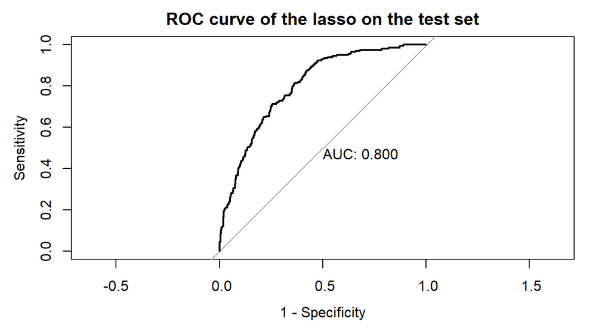

```r
plot(roc_test, legacy.axes = TRUE, print.auc = TRUE,
     main = "ROC curve of the lasso on the test set")
```

```r
# confusion matrix and measures for a given threshold
assess <- function(prob, truth, cutoff) {
  pred <- factor(ifelse(prob >= cutoff, "poor", "not_poor"), levels = c("not_poor", "poor"))
  cm <- confusionMatrix(pred, truth, positive = "poor")
  print(cm$table)
  data.frame(Threshold   = round(cutoff, 3),
             Accuracy    = round(unname(cm$overall["Accuracy"]), 3),
             Sensitivity = round(unname(cm$byClass["Sensitivity"]), 3),   # poor households found
             Specificity = round(unname(cm$byClass["Specificity"]), 3),   # not-poor households found
             Precision   = round(unname(cm$byClass["Pos Pred Value"]), 3))
}
cat("Threshold 0.5\n");  r1 <- assess(p_test, y_test, 0.5)
```

```
## Threshold 0.5
```

```
##           Reference
## Prediction not_poor poor
##   not_poor      630  123
##   poor           62   76
```

```r
cat("\nThreshold chosen on the training set\n"); r2 <- assess(p_test, y_test, thr)
```

```
##
## Threshold chosen on the training set
```

```
##           Reference
## Prediction not_poor poor
##   not_poor      479   52
##   poor          213  147
```

```r
res_tab <- rbind(r1, r2)
knitr::kable(res_tab, row.names = FALSE, caption = "Test set: lasso at two thresholds")
```

Test set: lasso at two thresholds

| Threshold | Accuracy | Sensitivity | Specificity | Precision |
| --- | --- | --- | --- | --- |
| 0.500 | 0.792 | 0.382 | 0.910 | 0.551 |
| 0.205 | 0.703 | 0.739 | 0.692 | 0.408 |

```r
# benchmark: accuracy of the rule "nobody is poor"
bench <- round(mean(y_test == "not_poor"), 3)
bench
```

```
## [1] 0.777
```

```r
# for information only: test AUC of all three methods (not used for the selection)
test_auc <- sapply(list(Lasso = fit_lasso, RandomForest = fit_rf, Boosting = fit_gbm),
  function(m) {
    p <- predict(m, newdata = x_test, type = "prob")[, "poor"]
    as.numeric(auc(roc(y_test, p, levels = c("not_poor", "poor"), direction = "<", quiet = TRUE)))
  })
round(test_auc, 3)
```

```
##        Lasso RandomForest     Boosting
##        0.800        0.806        0.814
```

**Results.** On the test set the lasso has an AUC of 0.8 (95% interval 0.768 to 0.833), to be compared with the cross-validated 0.833. Similar values mean that the model generalizes and there is no sign of overfitting. The AUC is the probability that a randomly chosen poor household gets a higher score than a randomly chosen non-poor one.

With the default threshold of 0.5 the model finds 38.2% of the poor households (sensitivity) and 91% of the non-poor ones (specificity). Its accuracy is 79.2%, to be compared with 77.7% for the rule “nobody is poor”: accuracy alone says little here. With the threshold 0.21 chosen on the training set, sensitivity becomes 73.9% and specificity 69.2%: the model finds more poor households, at the price of wrongly flagging more non-poor ones (precision 40.8%). Which threshold is right is a **policy decision**, because wrongly excluding a poor household and wrongly including a non-poor one have different costs.

# 12. Insights on the final model

**Which characteristics are associated with poverty?** Every category has its own 0/1 column, and numeric variables enter as they are. A positive coefficient raises the probability of being poor, a negative one lowers it, holding the other variables fixed (the unit is the log-odds). Coefficients of different types of variables are not comparable in size: a numeric coefficient is the effect of one unit, a category coefficient is the effect of belonging to that category. We therefore also show the **effect per standard deviation** (the coefficient times the standard deviation of its column): it measures the effect of a typical difference and is automatically small for rare categories.

```r
cf <- as.matrix(coef(fit_lasso$finalModel, s = best_lambda))[-1, 1]   # drop the intercept
cf <- cf[cf != 0]                                                      # columns kept
col_var <- col_to_var(names(cf))
eff <- data.frame(variable      = col_var,
                  type          = unname(var_type[col_var]),
                  column        = names(cf),
                  coefficient   = unname(cf),
                  effect_per_sd = unname(cf * apply(x_train[, names(cf), drop = FALSE], 2, sd)))
eff$direction <- ifelse(eff$coefficient > 0, "more poor", "less poor")
eff <- eff[order(-abs(eff$effect_per_sd)), ]
rownames(eff) <- NULL
nrow(eff)                                                              # columns kept by the lasso
```

```
## [1] 70
```

```r
eff_show <- data.frame(
  column        = eff$column,
  coefficient   = formatC(eff$coefficient, format = "fg", digits = 3),   # no scientific notation
  effect_per_sd = round(eff$effect_per_sd, 3))
knitr::kable(head(eff_show, 15), row.names = FALSE, align = "lrr",
             caption = "Lasso: the 15 largest effects per standard deviation (positive = more poor)")
```

Lasso: the 15 largest effects per standard deviation (positive = more poor)

| column | coefficient | effect_per_sd |
| --- | --- | --- |
| n_children_0_19 | 0.834 | 0.966 |
| monthly_rent | -0.00000574 | -0.654 |
| n_mobile_phones | -0.334 | -0.462 |
| household_size | -0.279 | -0.445 |
| n_tablets | -0.648 | -0.412 |
| persons_per_bedroom | 0.474 | 0.359 |
| mean_years_schooling_adults | -0.0651 | -0.284 |
| n_males_12plus | -0.303 | -0.277 |
| persons_living_in_dwelling | 0.143 | 0.244 |
| urban | 0.539 | 0.242 |
| head_education_level_undergraduate_or_higher | -0.634 | -0.234 |
| roof_quality_bad | 0.608 | 0.205 |
| n_bedrooms | 0.201 | 0.191 |
| head_disabled | 0.666 | 0.179 |
| n_seniors_65plus | 0.246 | 0.152 |

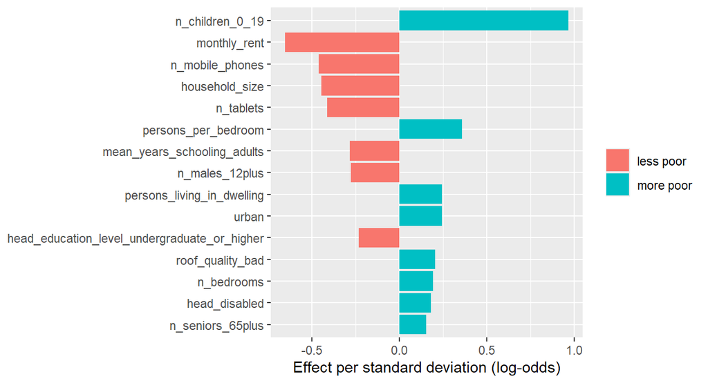

```r
ggplot(head(eff, 15), aes(reorder(column, abs(effect_per_sd)), effect_per_sd, fill = direction)) +
  geom_col() + coord_flip() +
  labs(x = NULL, y = "Effect per standard deviation (log-odds)", fill = NULL)
```

The two tree-based models give a second view that does not depend on the linear form (the importance tables above). Their top-10 rankings:

```r
top_rf  <- rownames(head(imp_rf, 10))
top_gbm <- rownames(head(imp_gbm, 10))
knitr::kable(data.frame(rank = 1:10, random_forest = top_rf, boosting = top_gbm))
```

| rank | random_forest | boosting |
| --- | --- | --- |
| 1 | mean_years_schooling_adults | mean_years_schooling_adults |
| 2 | head_age | dependency_rate |
| 3 | dependency_rate | persons_per_bedroom |
| 4 | head_years_schooling | n_children_0_19 |
| 5 | persons_per_bedroom | head_age |
| 6 | n_mobile_phones | n_mobile_phones |
| 7 | n_children_0_19 | has_ceiling |
| 8 | n_rooms | floor_quality_good |
| 9 | persons_living_in_dwelling | head_years_schooling |
| 10 | household_size | wall_material_block_or_brick |

```r
common <- intersect(top_rf, top_gbm)
common                                          # variables in both top-10 lists
```

```
## [1] "mean_years_schooling_adults" "head_age"
## [3] "dependency_rate"             "head_years_schooling"
## [5] "persons_per_bedroom"         "n_mobile_phones"
## [7] "n_children_0_19"
```

**What the model tells us**

- The three largest lasso effects are n_children_0_19, monthly_rent, n_mobile_phones. The variables in the top 10 of both the random forest and boosting are mean_years_schooling_adults, head_age, dependency_rate, head_years_schooling, persons_per_bedroom, n_mobile_phones, n_children_0_19. Variables that appear in several rankings are the most reliable signals.
- The exploratory analysis pointed to education, household composition, crowding and dwelling quality. Check in the tables above that the same groups of variables appear at the top; this is what the logic of a proxy means test would suggest.
- The lasso predicts about as well as the forest and boosting (test AUC: lasso 0.8, random forest 0.806, boosting 0.814). The relationship between the characteristics and poverty is therefore mostly additive and roughly linear on the log-odds scale.

**Limits of the model**

- The results are **associations, not causal effects**: giving a household a computer would not necessarily lift it out of poverty.
- Coefficients are conditional on all other variables, and correlated variables can take unexpected signs. For example `overcrowded_rooms` and `overcrowded_bedrooms` can get a negative coefficient, although crowded households are poorer on their own, because `persons_per_bedroom` already contains most of this information.
- An AUC of about 0.8 is a moderate discrimination: the characteristics predict poverty clearly better than chance (0.5), but a sizeable share of poor households look like non-poor ones. This is the known limit of proxy means tests under informality.
- The data describe the household head and the dwelling and come from one survey. The classes are imbalanced, so the choice of the threshold matters as much as the choice of the method.
- The test performance is estimated on one random split. A different split would give a slightly different number; the cross-validated AUC and its spread show how much.